# Exam 2 Take Home

St. Clair

Math 315 (Data Science) - due 11/9/16

## Your Name: Il Shan Ng

Five parts below are worth 10 points each, and two parts (1a and 2a) are worth 5 points each. This take home is worth a total of 60 points. These points will be added to your in-class exam that was worth 60 points. For each problem, your errors do not accumulate so a mistake in any data manipulation should not cost you additional points in parts that follow. Submit your .Rmd to the Courses folder by class time on Wednesday, 11/9.

### Problem 1

Use the `flights` data from `nycflights13` for this problem.

#### (1a) 5 points

Consider flights arriving at MSP from one of the three NYC area airports.

- Create a dataset from `flights` that only contain MSP destination flights.

```r
> flights2 <- flights %>% filter(dest == "MSP")
```

- Create a categorical variable that tells you if a flight’s arrival at MSP was delayed or not and a variable that tells you what day of the week a flight occurred.

```r
> flights2 <- flights2 %>%
+   mutate(
+     delay = ifelse(arr_delay > 0, 1, 0),     # 1 if delay, 0 if no delay
+     day_of_week = wday(time_hour, label = TRUE)
+     )
```

- Filter the data so it does not contain NA’s for the variables `hour`, `month`, `day`, `time_hour` and `arr_delay`.

```r
> apply(flights2[c("hour","month","day","time_hour","arr_delay")],
+       MARGIN = 2, function(var) length(which(is.na(var))))    # only arr_delay has NA values
     hour     month       day time_hour arr_delay
        0         0         0         0       256
>
> flights3 <- flights2 %>%
+   filter(!is.na(arr_delay))        # filter only based on arr_delay
```

- How many cases are in your data after this cleaning? What proportion of flights arrive at MSP behind schedule in 2013?

```r
> (num_cases <- nrow(flights3))
[1] 6929
>
> (prop_delay <- round(prop.table(with(flights3, table(delay)))[2], digits = 4))
     1
0.3998
```

*answer:* There are 6929 cases in the cleaned dataset. The proportion of flights that arrived behind schedule in 2013 is 0.3998.

#### (1b)

Create a logistic model using month, day of the month, day of the week, and hour of the flight to predict whether a flight will arrive late to MSP. Fit this model to a training set that contains a random sample of 75% of the flights to MSP and report your model’s accuracy on the test set.

```r
> set.seed(1)
> train_index <- sample(1:num_cases, size = round(0.75*num_cases))
> train_df <- flights3[train_index, ]
> test_df <- flights3[-train_index, ]
>
> flights.glm <- glm(delay ~ month + day + day_of_week + hour, family = "binomial", data = train_df)
>
> test_df <- test_df %>%
+   mutate(
+     prob_glm = predict(flights.glm, newdata = test_df, type = "response"),
+     pred_glm = ifelse(prob_glm >= 0.5, "1", "0")       # use threshold of 0.5
+     )
>
> (conf_mat <- with(test_df, table(delay, pred_glm)))
     pred_glm
delay   0   1
    0 868 188
    1 474 202
> (acc <- round(sum(diag(prop.table(conf_mat))), digits = 3))
[1] 0.618
```

*answer:* The logistic model’s accuracy on the test set is 0.618.

#### (1c)

Repeat (1b) for a random forest model.

```r
> rforest <- randomForest(as.factor(delay) ~ month + day + day_of_week + hour,
+                         data = train_df, ntree = 500, mtry = 2)   # response must be factor
>
> test_df <- test_df %>%
+   mutate(pred_rf = predict(rforest, newdata = test_df, type = "class"))
>
> (conf_mat2 <- with(test_df, table(delay, pred_rf)))
     pred_rf
delay   0   1
    0 816 240
    1 322 354
> (acc2 <- round(sum(diag(prop.table(conf_mat2))), digits = 3))
[1] 0.676
```

*answer:* The random forest model’s accuracy on the test set is 0.676.

#### (1d)

Create a ROC plot that shows the ROC curves for models (b) and (c) using the test data. Which model, if any, looks like it is a better predictor of arrival lateness?

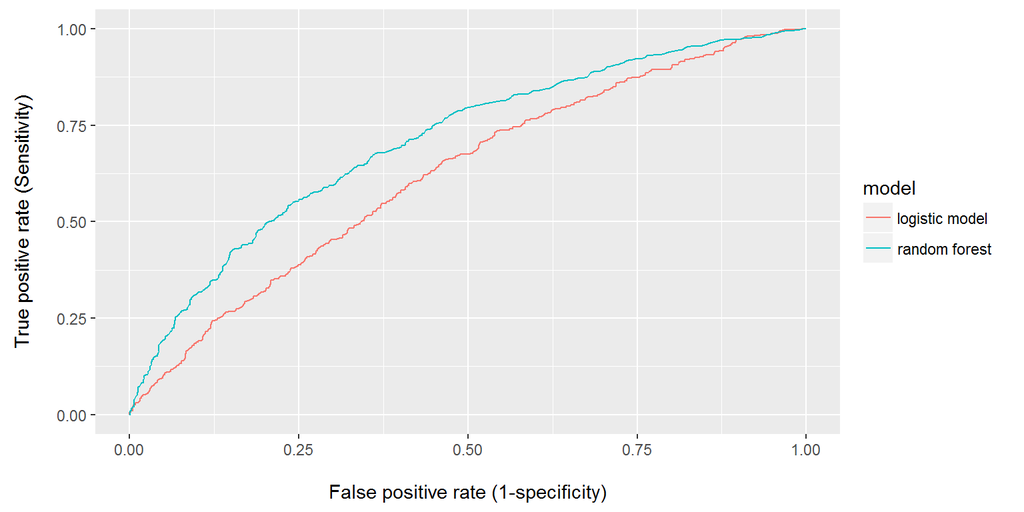

```r
> library(ROCR)
Warning: package 'ROCR' was built under R version 3.2.5
Warning: package 'gplots' was built under R version 3.2.5
>
> test_df <- test_df %>%
+   mutate(prob_rf = predict(rforest, newdata = test_df, type = "prob")[ ,2])
>
> perf_glm <- performance(prediction(test_df$prob_glm, test_df$delay), "tpr", "fpr")
> perf_rf <- performance(prediction(test_df$prob_rf, test_df$delay), "tpr", "fpr")
>
> ROC_df <- bind_rows(
+   data.frame(fpr = unlist(perf_glm@x.values),
+              tpr = unlist(perf_glm@y.values),
+              threshold = unlist(perf_glm@alpha.values),
+              model = "logistic model"),
+   data.frame(fpr = unlist(perf_rf@x.values),
+              tpr = unlist(perf_rf@y.values),
+              threshold = unlist(perf_rf@alpha.values),
+              model = "random forest")
+ )
Warning in bind_rows_(x, .id): Unequal factor levels: coercing to character
>
> ggplot(ROC_df, aes(x = fpr, y = tpr)) +
+   geom_line(aes(color = model)) +
+   labs(x = "\nFalse positive rate (1-specificity)",
+        y = "True positive rate (Sensitivity)\n")
```

*answer:* We see that the ROC curve for the random forest model (blue) is further away from the 45 degree line, as compared to that for the logistic model (red). That means that at any given false positive rate, the random forest model achieves a higher true positive rate (with possible exceptions near fpr = 0 or fpr = 1). Hence, the random forest model is a better predictor of arrival lateness.

## Problem 2

Use the url given below to scrape historic poll results from the 2008 election. Read this web page into R using `read_html`.

```r
> url <- "http://www.realclearpolitics.com/epolls/2008/president/us/general_election_mccain_vs_obama-225.html"
>
> poll.html <- read_html(url)
```

#### (2a) 5 points

After reading in the web page, extract the large polling data table on the web site (the large table, not the small one at the top of the web page). Create a `tbl` data frame out of this table to use in the questions below.

```r
> tables.html <- html_nodes(poll.html, "table")
> poll_df <- as.tbl(html_table(tables.html[[4]]))
```

#### (2b)

Remove the first two rows of the table, then out of the `Sample` variable create two variables in the data frame:

- `size` is a numeric variable that gives the survey size
- `sampleType` is a character variable that tells us the type of peopled surveyed (`RV` is registered voters, `LV` is likely voter, `A` is U.S. adult)

```r
> poll_df2 <- poll_df %>%
+   slice(-c(1,2)) %>%
+   mutate(size = extract_numeric(Sample),
+          sampleType = str_extract(Sample, "[A-Z]+"))
```

#### (2c)

Plot the sample size (x) versus the margin of error (`MoE`) for the polls and color by sample type. From Math 275, you should know that a rough measure of the margin of error for 95% confidence in a proportion is about $1/\sqrt{n}$. Multiply this by 100% to get the MoE for a percentage. Add this curvey to your plot and comment on how well this curve aligns, or doesn’t, with the survey’s stated MoE.

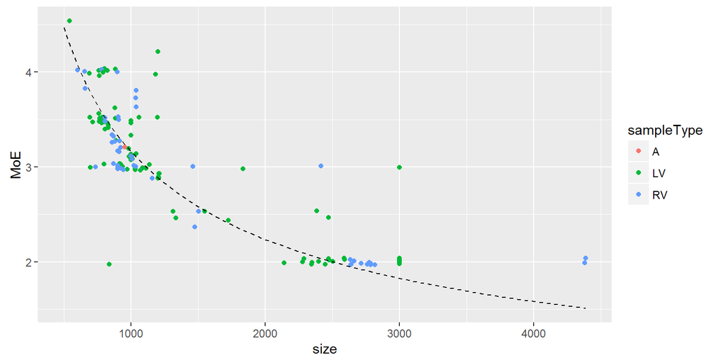

```r
> myFun <- function(x) 100/sqrt(x)
>
> poll_df2 %>%
+   mutate(MoE = as.numeric(MoE)) %>%
+   ggplot(aes(x = size, y = MoE)) +
+     geom_jitter(aes(color = sampleType)) +
+     stat_function(fun = myFun, geom = "line", color = "black", linetype = 2)
Warning in eval(substitute(expr), envir, enclos): NAs introduced by
coercion
Warning: Removed 164 rows containing missing values (geom_point).
```

*answer:* With the exception of a handful of outliers, most of the points lie close to the plotted curve. The curve therefore aligns pretty well with the survey’s reported MoE values.